# Projet Football

Luweh Adjim Ngarti Exaucé & Laamoumri Yassine

01/02/2022

# Profils

Le but de cette partie est de retrouver les équipes du championnant ayant des profils similaire.

On retire les variables statistiquement moins intéressant telles que l’année et le nombre de matchs puisque identiques pour tous les clubs.

```r
liga_2019 <- liga_2019 %>% select(-c("league","year","matches"))

liga_2019 <- as.data.frame(liga_2019)

# Concatenation nom du club et rang
liga_2019 <- liga_2019 %>%
  group_by(team) %>%
  mutate(team=paste(team,position))
```

```r
liga_2019 <- liga_2019 %>% remove_rownames %>% column_to_rownames(var="team")
liga_2019 <- liga_2019 %>% select(-c("position"))
```

## Equipes qui se ressemblent

### ACP

On effectue un ACP en considérant les points (*pts*) et (*xpts*) comme variables supplémentaire car c’est la variables qu’on compte prédire plus tard, il est donc de prime abord important d’étudier les interactions entre prédicteurs potentiels.

```r
res.pca <-
  PCA(
    liga_2019,
    quanti.sup = c(6,18,19),
    graph = FALSE
  )
```

```r
eig.val <- get_eigenvalue(res.pca)

eig.val
```

```
##          eigenvalue variance.percent cumulative.variance.percent
## Dim.1  9.523977e+00     5.952486e+01                    59.52486
## Dim.2  2.740017e+00     1.712511e+01                    76.64996
## Dim.3  1.580451e+00     9.877817e+00                    86.52778
## Dim.4  7.505169e-01     4.690731e+00                    91.21851
## Dim.5  5.628683e-01     3.517927e+00                    94.73644
## Dim.6  4.139885e-01     2.587428e+00                    97.32387
## Dim.7  1.876627e-01     1.172892e+00                    98.49676
## Dim.8  1.218774e-01     7.617337e-01                    99.25849
## Dim.9  6.341328e-02     3.963330e-01                    99.65483
## Dim.10 2.583032e-02     1.614395e-01                    99.81627
## Dim.11 1.898472e-02     1.186545e-01                    99.93492
## Dim.12 1.041281e-02     6.508003e-02                   100.00000
## Dim.13 1.175866e-30     7.349161e-30                   100.00000
## Dim.14 1.323658e-31     8.272864e-31                   100.00000
## Dim.15 2.822238e-32     1.763899e-31                   100.00000
## Dim.16 2.575554e-33     1.609721e-32                   100.00000
```

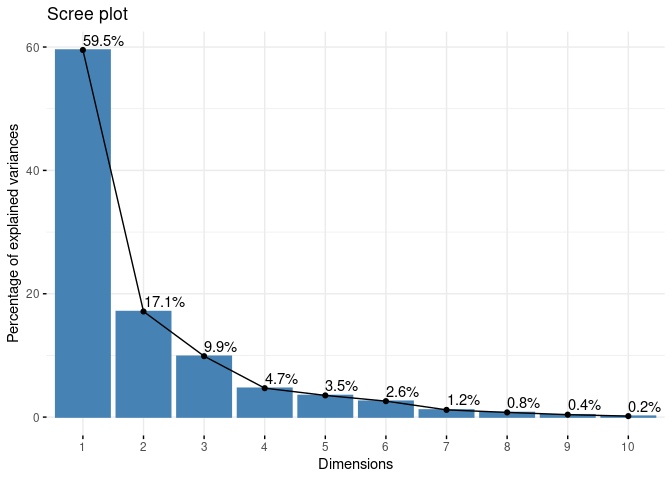

```r
fviz_eig(res.pca, addlabels = TRUE)
```

En utilisant la règle de **Kaser** c’est-à-dire garder que les axes ayant des valeurs propre supérieure à 1.(Car nous sommes dans un cas d’ACP normé et la plus petite variance est **1**)

```r
var <- get_pca_var(res.pca)
var
```

```
## Principal Component Analysis Results for variables
##  ===================================================
##   Name       Description
## 1 "$coord"   "Coordinates for the variables"
## 2 "$cor"     "Correlations between variables and dimensions"
## 3 "$cos2"    "Cos2 for the variables"
## 4 "$contrib" "contributions of the variables"
```

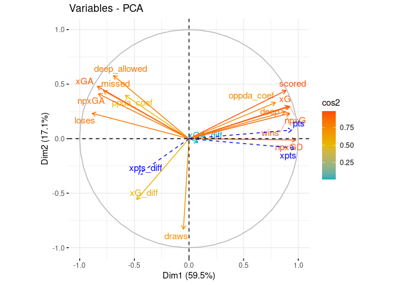

```r
eig.val <- get_eigenvalue(res.pca)

fviz_pca_var(res.pca,col.var = "cos2",gradient.cols = c("#00AFBB", "#E7B800", "#FC4E07"),repel = TRUE)
```

La première dimension sépare les équipes en deux groupes, à droite celles performantes caractérisées par un nombre élevé de buts ,de victoires, de bus attendus (*wins*, *scored*).. et à gauche celles qui ont moins performé.

La deuxième dimension quant à elle sépare les équipes sont sous-perforantes (qui ont manqué de réalisme) en bas de celles qui ont plus concretisé les occasions obtenues en haut. Elle sépare également les équipes tenues le plus en échec (un nombre de matchs nuls élevé) en bas (*draws* élevé) des autres.

Nous remarquons que beaucoup de variables sont linéairement corrélées.

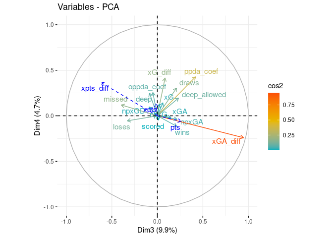

```r
fviz_pca_var(res.pca, axes = c(3:4),col.var = "cos2",gradient.cols = c("#00AFBB", "#E7B800", "#FC4E07"),repel = TRUE)
```

Ces deux dimensions contiennent très peu d’informations car la plus part des variables ne sont pas bien représentées. Les vecteurs sont loin du cercle

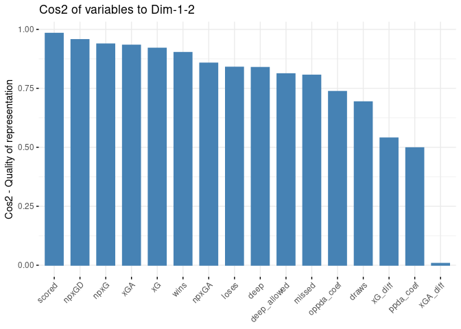

```r
fviz_cos2(res.pca, choice = 'var', axes = 1:2)
```

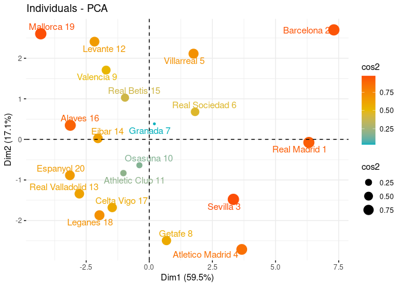

```r
fviz_pca_ind(res.pca,col.ind = "cos2",pointsize="cos2",gradient.cols= c("#00AFBB", "#E7B800", "#FC4E07"),repel=TRUE)
```

### Clustering

On remarque les équipes ayant sous-performées (en bas) ne sont toutes les moins bien classées car celles avec de belles statistiques en terme de but, points et passes sont plustôt bien classés. Le manque de réalisme n’est pas une fatalité, il faut logiquement le compenser en créant plus d’occasion.

On remarque que suivant la première dimension nous avons à droites les équipes les mieux classés.

Au delà ça il est pas évident de remarquer des groupes plus fins. Dans la suite nous allons faire une classification afin de mieux identifier les groupes des équipes et finalement vérifier si les équipes les mieux classés on des profils statistiques similaires.

#### Clustering

D’après l’ACP, plusieurs variables sont variables très corellées, nous allons garder que quelques unes.

```r
liga_2019 <- liga_2019 %>% select(-c( "xpts", "xpts_diff","xGA_diff", "xG_diff", "pts"))
```

```r
n <- nrow(liga_2019)
apply(liga_2019, 2, sd) # écart-type différents
```

```
##         wins        draws        loses       scored       missed           xG
##     5.561853     3.120391     5.599577    14.193772    11.049649    10.993496
##         npxG          xGA        npxGA        npxGD    ppda_coef   oppda_coef
##    10.609643     9.708017     8.087812    16.867951     1.763170     2.744962
##         deep deep_allowed
##    79.940438    47.996162
```

On décide de travailler sur les données standardisées au vu de l’échelle des ecart-types.

```r
data_sd <- as.data.frame(scale(liga_2019, center=TRUE,scale=TRUE)*sqrt(n/(n-1)))

#rownames(data_sd) <- rownames(liga_2019)
rownames(as.data.frame(liga_2019))
```

```
##  [1] "Real Madrid 1"      "Barcelona 2"        "Sevilla 3"
##  [4] "Atletico Madrid 4"  "Villarreal 5"       "Real Sociedad 6"
##  [7] "Granada 7"          "Getafe 8"           "Valencia 9"
## [10] "Osasuna 10"         "Athletic Club 11"   "Levante 12"
## [13] "Real Valladolid 13" "Eibar 14"           "Real Betis 15"
## [16] "Alaves 16"          "Celta Vigo 17"      "Leganes 18"
## [19] "Mallorca 19"        "Espanyol 20"
```

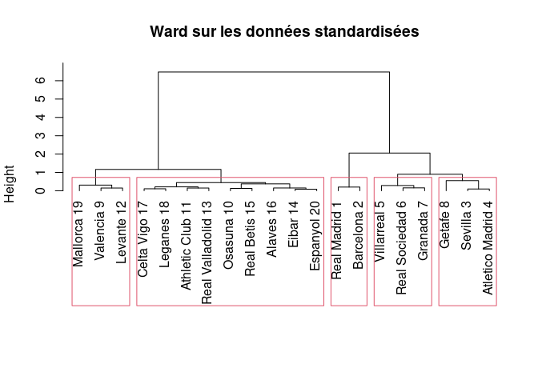

```r
# Choix du nombre de classes
k=5

# Graphique du dendrogramme


#Clustering par CAH de Ward sur les données standardisée

distance <- dist(data_sd)
tree <- hclust(distance^2/(2*n),method = "ward.D")



# Graphique du dendrogramme

plot(tree, hang=-1, main="Ward sur les données standardisées", sub="", xlab="")
rect.hclust(tree,k=k)
```

On voit que parmis les équipes bien classées un clustering permet de retrouver les meilleurs c’est-à-dire les statistiques suffisent pour expliquer qu’une équipe performe mieux qu’une autre. En revance pour la moitié inférieure du tableau, il est plus compliqué. Cela peut être du au fait que la réussite ne dépend pas uniquement des statistiques considerées, raison pour laquelle dans la suite nous allons considérer d’autres variables.

Nous allons tout de même chercher à comprendre les variables qui caractérisent les diférents clusters.

```r
part <- cutree(tree,k=k)
part <- as.factor(part)
levels(part) <- paste("cluster",1:k,sep="")
res <- PCA(data.frame(part, data_sd), quali.sup=1,quanti.sup = 4,graph=FALSE,scale.unit = FALSE)
res$eig
```

```
##           eigenvalue percentage of variance cumulative percentage of variance
## comp 1  8.538023e+00           6.567710e+01                          65.67710
## comp 2  2.445806e+00           1.881389e+01                          84.49100
## comp 3  7.795909e-01           5.996853e+00                          90.48785
## comp 4  5.030311e-01           3.869470e+00                          94.35732
## comp 5  2.885641e-01           2.219724e+00                          96.57704
## comp 6  1.605372e-01           1.234901e+00                          97.81194
## comp 7  1.270091e-01           9.769927e-01                          98.78894
## comp 8  8.140844e-02           6.262188e-01                          99.41516
## comp 9  3.775461e-02           2.904200e-01                          99.70558
## comp 10 1.512203e-02           1.163233e-01                          99.82190
## comp 11 1.411315e-02           1.085627e-01                          99.93046
## comp 12 9.040042e-03           6.953878e-02                         100.00000
## comp 13 1.474945e-31           1.134573e-30                         100.00000
```

Bonne représentation sur le plan factoriel 1-2 (84,49% d’information retrouvée)

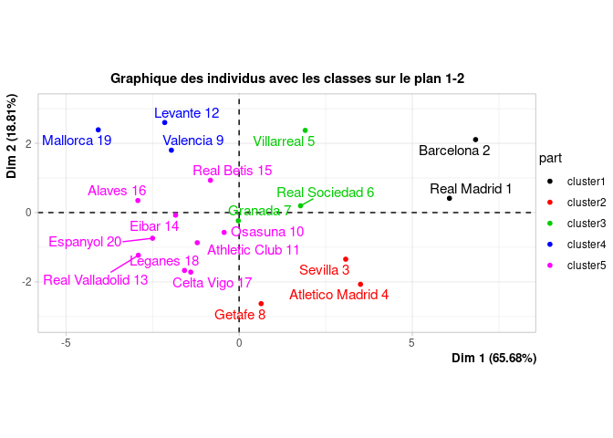

```r
plot(res,habillage=1,invisible="quali",title="Graphique des individus avec les classes sur le plan 1-2") #
```

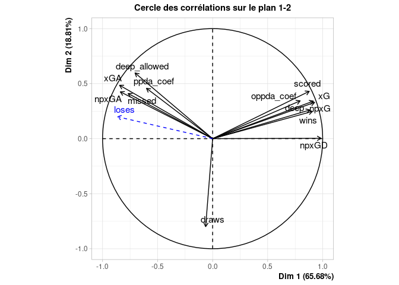

```r
plot(res,choix="var",title="Cercle des corrélations sur le plan 1-2")
```